# Project: TMDB 5000 Movie Dataset Analysis

- Introduction
- Data Wrangling
- Exploratory Data Analysis
- Conclusions
- References

## Introduction

**Note**: There are no questions yet to start analysis with. The above description of the data is from the source from where the data is downloaded initially. The reference link for the data source is provided in the **References** section at the end. Therefore, the questions over which the analysis is to be done, are yet to be formed after exploration is done.

Let's import all the necessary libraries to be used ahead

```python
# Import necessary Pandas Libraries
import numpy as np
import pandas as pd
import matplotlib.pyplot as plt
import seaborn as sns

# Magic words usage to show plots within the document
%matplotlib inline
```

## Data Wrangling

In this section of the report, we will load in the data, check for cleanliness, and then trim and clean our dataset for analysis.

### General Properties

**1. Load in the datasets and check for first five rows**

```python
# Load and perform operations to inspect first dataset
df_credits = pd.read_csv("C:/Users/yashm/Documents/Data_Analyst_DAND/Python_Project_1/Project_Investigate_Dataset/Data/tmdb_5000_credits.csv")
df_credits.head()
```

|  | movie_id | title | cast | crew |
| --- | --- | --- | --- | --- |
| 0 | 19995 | Avatar | [{"cast_id": 242, "character": "Jake Sully", "... | [{"credit_id": "52fe48009251416c750aca23", "de... |
| 1 | 285 | Pirates of the Caribbean: At World's End | [{"cast_id": 4, "character": "Captain Jack Spa... | [{"credit_id": "52fe4232c3a36847f800b579", "de... |
| 2 | 206647 | Spectre | [{"cast_id": 1, "character": "James Bond", "cr... | [{"credit_id": "54805967c3a36829b5002c41", "de... |
| 3 | 49026 | The Dark Knight Rises | [{"cast_id": 2, "character": "Bruce Wayne / Ba... | [{"credit_id": "52fe4781c3a36847f81398c3", "de... |
| 4 | 49529 | John Carter | [{"cast_id": 5, "character": "John Carter", "c... | [{"credit_id": "52fe479ac3a36847f813eaa3", "de... |

```python
# Load and perform operations to inspect second dataset
df_mov = pd.read_csv("C:/Users/yashm/Documents/Data_Analyst_DAND/Python_Project_1/Project_Investigate_Dataset/Data/tmdb_5000_movies.csv")
df_mov.head(2)
```

|  | budget | genres | homepage | id | keywords | original_language | original_title | overview | popularity | production_companies | production_countries | release_date | revenue | runtime | spoken_languages | status | tagline | title | vote_average | vote_count |
| --- | --- | --- | --- | --- | --- | --- | --- | --- | --- | --- | --- | --- | --- | --- | --- | --- | --- | --- | --- | --- |
| 0 | 237000000 | [{"id": 28, "name": "Action"}, {"id": 12, "nam... | http://www.avatarmovie.com/ | 19995 | [{"id": 1463, "name": "culture clash"}, {"id":... | en | Avatar | In the 22nd century, a paraplegic Marine is di... | 150.437577 | [{"name": "Ingenious Film Partners", "id": 289... | [{"iso_3166_1": "US", "name": "United States o... | 2009-12-10 | 2787965087 | 162.0 | [{"iso_639_1": "en", "name": "English"}, {"iso... | Released | Enter the World of Pandora. | Avatar | 7.2 | 11800 |
| 1 | 300000000 | [{"id": 12, "name": "Adventure"}, {"id": 14, "... | http://disney.go.com/disneypictures/pirates/ | 285 | [{"id": 270, "name": "ocean"}, {"id": 726, "na... | en | Pirates of the Caribbean: At World's End | Captain Barbossa, long believed to be dead, ha... | 139.082615 | [{"name": "Walt Disney Pictures", "id": 2}, {"... | [{"iso_3166_1": "US", "name": "United States o... | 2007-05-19 | 961000000 | 169.0 | [{"iso_639_1": "en", "name": "English"}] | Released | At the end of the world, the adventure begins. | Pirates of the Caribbean: At World's End | 6.9 | 4500 |

**2. Check the general structure of both the datasets**

```python
# Check the shape of the first dataset
df_credits.shape
```

```
(4803, 4)
```

```python
# Check the shape of the second dataset
df_mov.shape
```

```
(4803, 20)
```

**df_credits has 4803 rows and 4 columns while df_mov has 4803 rows and 20 columns. Let's explore further**

```python
# Check for the duplicates in the first dataset
sum(df_credits.duplicated())
```

```
0
```

```python
# Check for the duplicates in the second dataset
sum(df_mov.duplicated())
```

```
0
```

**Both the datasets do not have any duplicate rows**

```python
# Check for the datatypes of each variable in the first dataset
df_credits.dtypes
```

```
movie_id     int64
title       object
cast        object
crew        object
dtype: object
```

**Datatypes of df_credits as shown above**

```python
# Check for the datatypes of each variable in the second dataset
df_mov.dtypes
```

```
budget                    int64
genres                   object
homepage                 object
id                        int64
keywords                 object
original_language        object
original_title           object
overview                 object
popularity              float64
production_companies     object
production_countries     object
release_date             object
revenue                   int64
runtime                 float64
spoken_languages         object
status                   object
tagline                  object
title                    object
vote_average            float64
vote_count                int64
dtype: object
```

**Datatypes of df_mov as shown above**

**Issues:**

1. `release_date` variable should be of the form datetime

```python
# Check for unique values in each variable in the first dataset
df_credits.nunique()
```

```
movie_id    4803
title       4800
cast        4761
crew        4776
dtype: int64
```

**While there are 4803 movies in total, there are only 4800 unique titles which suggest the presence of duplicates**

```python
# Check for unique values in each variable in the second dataset
df_mov.nunique()
```

```
budget                   436
genres                  1175
homepage                1691
id                      4803
keywords                4222
original_language         37
original_title          4801
overview                4800
popularity              4802
production_companies    3697
production_countries     469
release_date            3280
revenue                 3297
runtime                  156
spoken_languages         544
status                     3
tagline                 3944
title                   4800
vote_average              71
vote_count              1609
dtype: int64
```

**Issues**

1. While there are 4803 movies in total, there are only 4800 unique titles and which suggest the presence of duplicates
2. There are 4800 titles but 4801 original titles which suggests further investigation in the 2 variables
3. There are 4802 unique popularity values instead of 4803 which suggests presence of duplicates
4. Status has only 3 unique values which needs further investigation to find if we need all the observations or some of them can be removed

```python
# Check for detailed info in the first dataset
df_credits.info()
```

```
<class 'pandas.core.frame.DataFrame'>
RangeIndex: 4803 entries, 0 to 4802
Data columns (total 4 columns):
movie_id    4803 non-null int64
title       4803 non-null object
cast        4803 non-null object
crew        4803 non-null object
dtypes: int64(1), object(3)
memory usage: 150.2+ KB
```

```python
# Check for detailed info in the second dataset
df_mov.info()
```

```
<class 'pandas.core.frame.DataFrame'>
RangeIndex: 4803 entries, 0 to 4802
Data columns (total 20 columns):
budget                  4803 non-null int64
genres                  4803 non-null object
homepage                1712 non-null object
id                      4803 non-null int64
keywords                4803 non-null object
original_language       4803 non-null object
original_title          4803 non-null object
overview                4800 non-null object
popularity              4803 non-null float64
production_companies    4803 non-null object
production_countries    4803 non-null object
release_date            4802 non-null object
revenue                 4803 non-null int64
runtime                 4801 non-null float64
spoken_languages        4803 non-null object
status                  4803 non-null object
tagline                 3959 non-null object
title                   4803 non-null object
vote_average            4803 non-null float64
vote_count              4803 non-null int64
dtypes: float64(3), int64(4), object(13)
memory usage: 750.5+ KB
```

**Presence of null values can be seen in some variables namely - `homepage`, `overview`, `release_date`, `runtime`, and `tagline`**

**3. Explore further the count of each unique value in the `status` variable as mentioned above**

```python
df_mov.status.value_counts()
```

```
Released           4795
Rumored               5
Post Production       3
Name: status, dtype: int64
```

**It can be seen that there are almost all the obseravtions which belong to `Released` status. Therefore, we need to limit the dataset to this value of status only as including other status types also makes no sense**

**4. As the presence of null values is detected above, we need to see the null counts in each variable of df_mov**

```python
df_mov.isnull().sum()
```

```
budget                     0
genres                     0
homepage                3091
id                         0
keywords                   0
original_language          0
original_title             0
overview                   3
popularity                 0
production_companies       0
production_countries       0
release_date               1
revenue                    0
runtime                    2
spoken_languages           0
status                     0
tagline                  844
title                      0
vote_average               0
vote_count                 0
dtype: int64
```

**There are huge number of null counts in `homepage` followed by `tagline`. These are the variables which we might not even require in our further analysis**

**5. As we saw above `original_title` and `title` unique values did not match, so we need to explore them further**

```python
# Check the instances where original title do not match with title column
df_mov[['original_title', 'title']].query('original_title != title')
```

|  | original_title | title |
| --- | --- | --- |
| 97 | シン・ゴジラ | Shin Godzilla |
| 215 | 4: Rise of the Silver Surfer | Fantastic 4: Rise of the Silver Surfer |
| 235 | Astérix aux Jeux Olympiques | Asterix at the Olympic Games |
| 317 | 金陵十三釵 | The Flowers of War |
| 474 | Évolution | Evolution |
| 488 | Arthur et les Minimoys | Arthur and the Invisibles |
| 492 | Don Gato: El inicio de la pandilla | Top Cat Begins |
| 561 | Deux frères | Two Brothers |
| 678 | 天將雄師 | Dragon Blade |
| 719 | Michael Jackson's This Is It | This Is It |
| 786 | 西游记之孙悟空三打白骨精 | The Monkey King 2 |
| 861 | Un long dimanche de fiançailles | A Very Long Engagement |
| 985 | Joan of Arc | The Messenger: The Story of Joan of Arc |
| 1023 | 1947: Earth | Earth |
| 1028 | Солярис | Solaris |
| 1095 | 滿城盡帶黃金甲 | Curse of the Golden Flower |
| 1136 | 英雄 | Hero |
| 1140 | Micmacs à tire-larigot | Micmacs |
| 1142 | Pourquoi j'ai pas mangé mon père | Why I Did (Not) Eat My Father |
| 1255 | Lo imposible | The Impossible |
| 1260 | Le fabuleux destin d'Amélie Poulain | Amélie |
| 1284 | 投名狀 | The Warlords |
| 1285 | Nomad | Nomad: The Warrior |
| 1287 | Un monstre à Paris | A Monster in Paris |
| 1298 | Chi bi | Red Cliff |
| 1304 | 一代宗師 | The Grandmaster |
| 1341 | Obitaemyy Ostrov | The Inhabited Island |
| 1357 | 葉問3 | Ip Man 3 |
| 1460 | Le Hussard sur le toit | The Horseman on the Roof |
| 1471 | 崖の上のポニョ | Ponyo |
| ... | ... | ... |
| 4434 | 4 luni, 3 săptămîni și 2 zile | 4 Months, 3 Weeks and 2 Days |
| 4444 | Le bonheur d'Elza | Elza |
| 4452 | جدایی نادر از سیمین | A Separation |
| 4457 | Die Büchse der Pandora | Pandora's Box |
| 4459 | Cama adentro | Live-In Maid |
| 4464 | Død snø | Dead Snow |
| 4474 | Il conformista | The Conformist |
| 4482 | L.I.E. Long Island Expressway | L.I.E. |
| 4500 | Arnolds Park | Carousel of Revenge |
| 4505 | Médecin de campagne | The Country Doctor |
| 4510 | Julija in Alfa Romeo | Juliet and Alfa Romeo |
| 4535 | 七人の侍 | Seven Samurai |
| 4536 | Kita svajonių komanda | The Other Dream Team |
| 4546 | 疯狂的石头 | Crazy Stone |
| 4573 | Så som i himmelen | As It Is in Heaven |
| 4585 | ...E tu vivrai nel terrore! L'aldilà | The Beyond |
| 4591 | Viskningar och rop | Cries and Whispers |
| 4605 | Κυνόδοντας | Dogtooth |
| 4609 | Chacun Cherche Son Chat | When the Cat's Away |
| 4615 | Pierrot le fou | Pierrot le Fou |
| 4672 | Per un pugno di dollari | A Fistful of Dollars |
| 4677 | Drei | Three |
| 4684 | Solitude | American Beast |
| 4685 | Chats perchés | The Case of the Grinning Cat |
| 4695 | بچه‌های آسمان | Children of Heaven |
| 4699 | Lumea e a mea | The World Is Mine |
| 4719 | Une femme mariée: Suite de fragments d'un film... | The Married Woman |
| 4751 | Gabriela, Cravo e Canela | Gabriela |
| 4790 | دایره | The Circle |
| 4792 | キュア | Cure |

261 rows × 2 columns

**So, we saw that there are 261 instances where `original_title` doesn't match with `title`. So, it's possible that number of unique values differ in both the columns. Therefore, we are on the same place as before that we need to explore `title` column further which we will do in the *Further Exploration and Cleaning* section**

### Further Exploration and Cleaning

#### Issues to be resolved:

1. Filter df_mov to the observations with Released status in the new dataset cl_mov which is always a good decision because we might need the original dataset at any time in the analysis
2. Drop the unnecessary columns
3. Drop the null observations in any variable
4. Explore and check title variable further for duplicates in df_mov
5. change the data type of the `release_date` to datetime in df_mov
6. Try to resolve the variables that you find difficult to explore

This section will be a follow up of the previous section. Here, we will clean and further explore the issues that we observed above. We will go stepwise as before:

**1. Filter df_mov to the observations with *Released* status in the new dataset cl_mov which is always a good decision because we might need the original dataset at any time in the analysis**

```python
# Filter df_mov with status 'Released'
cl_mov = df_mov[df_mov['status'] == "Released"]
cl_mov.head(2)
```

|  | budget | genres | homepage | id | keywords | original_language | original_title | overview | popularity | production_companies | production_countries | release_date | revenue | runtime | spoken_languages | status | tagline | title | vote_average | vote_count |
| --- | --- | --- | --- | --- | --- | --- | --- | --- | --- | --- | --- | --- | --- | --- | --- | --- | --- | --- | --- | --- |
| 0 | 237000000 | [{"id": 28, "name": "Action"}, {"id": 12, "nam... | http://www.avatarmovie.com/ | 19995 | [{"id": 1463, "name": "culture clash"}, {"id":... | en | Avatar | In the 22nd century, a paraplegic Marine is di... | 150.437577 | [{"name": "Ingenious Film Partners", "id": 289... | [{"iso_3166_1": "US", "name": "United States o... | 2009-12-10 | 2787965087 | 162.0 | [{"iso_639_1": "en", "name": "English"}, {"iso... | Released | Enter the World of Pandora. | Avatar | 7.2 | 11800 |
| 1 | 300000000 | [{"id": 12, "name": "Adventure"}, {"id": 14, "... | http://disney.go.com/disneypictures/pirates/ | 285 | [{"id": 270, "name": "ocean"}, {"id": 726, "na... | en | Pirates of the Caribbean: At World's End | Captain Barbossa, long believed to be dead, ha... | 139.082615 | [{"name": "Walt Disney Pictures", "id": 2}, {"... | [{"iso_3166_1": "US", "name": "United States o... | 2007-05-19 | 961000000 | 169.0 | [{"iso_639_1": "en", "name": "English"}] | Released | At the end of the world, the adventure begins. | Pirates of the Caribbean: At World's End | 6.9 | 4500 |

```python
# confirm only status is "Released"
cl_mov.status.unique()
```

```
array(['Released'], dtype=object)
```

**2. Drop the unnecessary columns**

```python
# Drop columns not required further for analysis
cl_mov.drop(['homepage', 'keywords', 'original_language', 'original_title', 'tagline', 'overview', 'spoken_languages', 'status'], axis=1, inplace = True)
cl_mov.head(2)
```

|  | budget | genres | id | popularity | production_companies | production_countries | release_date | revenue | runtime | title | vote_average | vote_count |
| --- | --- | --- | --- | --- | --- | --- | --- | --- | --- | --- | --- | --- |
| 0 | 237000000 | [{"id": 28, "name": "Action"}, {"id": 12, "nam... | 19995 | 150.437577 | [{"name": "Ingenious Film Partners", "id": 289... | [{"iso_3166_1": "US", "name": "United States o... | 2009-12-10 | 2787965087 | 162.0 | Avatar | 7.2 | 11800 |
| 1 | 300000000 | [{"id": 12, "name": "Adventure"}, {"id": 14, "... | 285 | 139.082615 | [{"name": "Walt Disney Pictures", "id": 2}, {"... | [{"iso_3166_1": "US", "name": "United States o... | 2007-05-19 | 961000000 | 169.0 | Pirates of the Caribbean: At World's End | 6.9 | 4500 |

```python
# Check the shape again of cl_mov
cl_mov.shape
```

```
(4795, 12)
```

```python
# Check the null counts again of cl_mov
cl_mov.isnull().sum()
```

```
budget                  0
genres                  0
id                      0
popularity              0
production_companies    0
production_countries    0
release_date            1
revenue                 0
runtime                 2
title                   0
vote_average            0
vote_count              0
dtype: int64
```

**3. Now, cl_mov looks much better and the null counts are so less that we can directly drop the null observations in any variable**

```python
cl_mov.dropna(inplace = True)
```

```python
# Check the shape again of cl_mov
cl_mov.shape
```

```
(4792, 12)
```

**4. As we saw in the previous section, the `title` may have duplicates. So, check if there are any duplicates with respect to `title` variable**

```python
# Check for duplicates in the title variable in cl_mov
cl_mov[cl_mov['title'].duplicated() == True]
```

|  | budget | genres | id | popularity | production_companies | production_countries | release_date | revenue | runtime | title | vote_average | vote_count |
| --- | --- | --- | --- | --- | --- | --- | --- | --- | --- | --- | --- | --- |
| 2877 | 11000000 | [{"id": 27, "name": "Horror"}, {"id": 18, "nam... | 1255 | 27.655270 | [{"name": "Cineclick Asia", "id": 685}, {"name... | [{"iso_3166_1": "KR", "name": "South Korea"}] | 2006-07-27 | 88489643 | 119.0 | The Host | 6.7 | 537 |
| 3693 | 0 | [{"id": 18, "name": "Drama"}] | 10844 | 0.706355 | [] | [{"iso_3166_1": "NZ", "name": "New Zealand"}] | 2006-10-12 | 0 | 103.0 | Out of the Blue | 5.9 | 18 |
| 4267 | 1377800 | [{"id": 10751, "name": "Family"}, {"id": 12, "... | 2661 | 9.815394 | [{"name": "Twentieth Century Fox Film Corporat... | [{"iso_3166_1": "US", "name": "United States o... | 1966-07-30 | 0 | 105.0 | Batman | 6.1 | 203 |

**5. Check for individual duplicate titles**

```python
cl_mov[cl_mov['title'].str.contains('Out of the Blue')]
```

|  | budget | genres | id | popularity | production_companies | production_countries | release_date | revenue | runtime | title | vote_average | vote_count |
| --- | --- | --- | --- | --- | --- | --- | --- | --- | --- | --- | --- | --- |
| 3647 | 0 | [{"id": 18, "name": "Drama"}] | 39269 | 0.679351 | [{"name": "Robson Street", "id": 71953}] | [{"iso_3166_1": "CA", "name": "Canada"}] | 1980-05-01 | 0 | 94.0 | Out of the Blue | 6.5 | 17 |
| 3693 | 0 | [{"id": 18, "name": "Drama"}] | 10844 | 0.706355 | [] | [{"iso_3166_1": "NZ", "name": "New Zealand"}] | 2006-10-12 | 0 | 103.0 | Out of the Blue | 5.9 | 18 |

```python
cl_mov[cl_mov['title'].str.contains('The Host')]
```

|  | budget | genres | id | popularity | production_companies | production_countries | release_date | revenue | runtime | title | vote_average | vote_count |
| --- | --- | --- | --- | --- | --- | --- | --- | --- | --- | --- | --- | --- |
| 972 | 44000000 | [{"id": 28, "name": "Action"}, {"id": 12, "nam... | 72710 | 42.933027 | [{"name": "Nick Wechsler Productions", "id": 8... | [{"iso_3166_1": "US", "name": "United States o... | 2013-03-22 | 63327201 | 125.0 | The Host | 6.0 | 1817 |
| 2877 | 11000000 | [{"id": 27, "name": "Horror"}, {"id": 18, "nam... | 1255 | 27.655270 | [{"name": "Cineclick Asia", "id": 685}, {"name... | [{"iso_3166_1": "KR", "name": "South Korea"}] | 2006-07-27 | 88489643 | 119.0 | The Host | 6.7 | 537 |

```python
cl_mov[cl_mov['title'].str.contains('Batman')]
```

|  | budget | genres | id | popularity | production_companies | production_countries | release_date | revenue | runtime | title | vote_average | vote_count |
| --- | --- | --- | --- | --- | --- | --- | --- | --- | --- | --- | --- | --- |
| 9 | 250000000 | [{"id": 28, "name": "Action"}, {"id": 12, "nam... | 209112 | 155.790452 | [{"name": "DC Comics", "id": 429}, {"name": "A... | [{"iso_3166_1": "US", "name": "United States o... | 2016-03-23 | 873260194 | 151.0 | Batman v Superman: Dawn of Justice | 5.7 | 7004 |
| 119 | 150000000 | [{"id": 28, "name": "Action"}, {"id": 80, "nam... | 272 | 115.040024 | [{"name": "DC Comics", "id": 429}, {"name": "L... | [{"iso_3166_1": "GB", "name": "United Kingdom"... | 2005-06-10 | 374218673 | 140.0 | Batman Begins | 7.5 | 7359 |
| 210 | 125000000 | [{"id": 28, "name": "Action"}, {"id": 80, "nam... | 415 | 50.073575 | [{"name": "PolyGram Filmed Entertainment", "id... | [{"iso_3166_1": "GB", "name": "United Kingdom"... | 1997-06-20 | 238207122 | 125.0 | Batman & Robin | 4.2 | 1418 |
| 299 | 100000000 | [{"id": 28, "name": "Action"}, {"id": 80, "nam... | 414 | 48.205606 | [{"name": "Warner Bros.", "id": 6194}, {"name"... | [{"iso_3166_1": "GB", "name": "United Kingdom"... | 1995-05-31 | 336529144 | 121.0 | Batman Forever | 5.2 | 1498 |
| 428 | 80000000 | [{"id": 28, "name": "Action"}, {"id": 14, "nam... | 364 | 59.113174 | [{"name": "PolyGram Filmed Entertainment", "id... | [{"iso_3166_1": "GB", "name": "United Kingdom"... | 1992-06-19 | 280000000 | 126.0 | Batman Returns | 6.6 | 1673 |
| 1359 | 35000000 | [{"id": 14, "name": "Fantasy"}, {"id": 28, "na... | 268 | 44.104469 | [{"name": "PolyGram Filmed Entertainment", "id... | [{"iso_3166_1": "GB", "name": "United Kingdom"... | 1989-06-23 | 411348924 | 126.0 | Batman | 7.0 | 2096 |
| 3854 | 3500000 | [{"id": 28, "name": "Action"}, {"id": 16, "nam... | 142061 | 25.891466 | [{"name": "DC Comics", "id": 429}, {"name": "W... | [{"iso_3166_1": "US", "name": "United States o... | 2013-01-18 | 0 | 78.0 | Batman: The Dark Knight Returns, Part 2 | 7.9 | 419 |
| 4267 | 1377800 | [{"id": 10751, "name": "Family"}, {"id": 12, "... | 2661 | 9.815394 | [{"name": "Twentieth Century Fox Film Corporat... | [{"iso_3166_1": "US", "name": "United States o... | 1966-07-30 | 0 | 105.0 | Batman | 6.1 | 203 |

**So, we observed that our intuition was wrong and there can be two or more movies with the same name**

**6. Now form a copy of the df_credits as cl_cr to explore and clean it further**

```python
cl_cr = df_credits
```

**7. Drop the unnecessary columns in cl_cr**

```python
cl_cr.drop(['crew'], axis=1, inplace=True)
cl_cr.head(2)
```

|  | movie_id | title | cast |
| --- | --- | --- | --- |
| 0 | 19995 | Avatar | [{"cast_id": 242, "character": "Jake Sully", "... |
| 1 | 285 | Pirates of the Caribbean: At World's End | [{"cast_id": 4, "character": "Captain Jack Spa... |

**8. As discussed in the previous section, change the data type of the `release_date` to datetime**

```python
cl_mov['release_date'] = pd.to_datetime(cl_mov['release_date'])
cl_mov.dtypes
```

```
budget                           int64
genres                          object
id                               int64
popularity                     float64
production_companies            object
production_countries            object
release_date            datetime64[ns]
revenue                          int64
runtime                        float64
title                           object
vote_average                   float64
vote_count                       int64
dtype: object
```

**9. Now, although we are aware of every variable data type in cl_mov, but still there are variables which we are finding difficult to explore and use it further. I tried to resolve one such variable `genres`**

```python
x = []
for item in cl_mov['genres']:
    for dice in item:
        for value in dice:
            x.append(value)
x[0:10]
```

```
['[', '{', '"', 'i', 'd', '"', ':', ' ', '2', '8']
```

```python
cl_mov['genres'].items()
```

```
<zip at 0x183e333dd48>
```

```python
genre_details = list(map(str,(cl_mov['genres'])))
genre_details[0:10]
```

```
['[{"id": 28, "name": "Action"}, {"id": 12, "name": "Adventure"}, {"id": 14, "name": "Fantasy"}, {"id": 878, "name": "Science Fiction"}]',
 '[{"id": 12, "name": "Adventure"}, {"id": 14, "name": "Fantasy"}, {"id": 28, "name": "Action"}]',
 '[{"id": 28, "name": "Action"}, {"id": 12, "name": "Adventure"}, {"id": 80, "name": "Crime"}]',
 '[{"id": 28, "name": "Action"}, {"id": 80, "name": "Crime"}, {"id": 18, "name": "Drama"}, {"id": 53, "name": "Thriller"}]',
 '[{"id": 28, "name": "Action"}, {"id": 12, "name": "Adventure"}, {"id": 878, "name": "Science Fiction"}]',
 '[{"id": 14, "name": "Fantasy"}, {"id": 28, "name": "Action"}, {"id": 12, "name": "Adventure"}]',
 '[{"id": 16, "name": "Animation"}, {"id": 10751, "name": "Family"}]',
 '[{"id": 28, "name": "Action"}, {"id": 12, "name": "Adventure"}, {"id": 878, "name": "Science Fiction"}]',
 '[{"id": 12, "name": "Adventure"}, {"id": 14, "name": "Fantasy"}, {"id": 10751, "name": "Family"}]',
 '[{"id": 28, "name": "Action"}, {"id": 12, "name": "Adventure"}, {"id": 14, "name": "Fantasy"}]']
```

```python
genre = []
for i in genre_details:
    split_genre = list(map(str, i.split('[')))
    for j in split_genre:
        if j not in genre:
            genre.append(j)
print(genre[0:10])
```

[output not shown]

## Exploratory Data Analysis

So, now, as the title suggests, we are ready for **Exploratory Data Analysis**. As we know, we need to form questions for further research and analysis, this part will help us form those questions after we explore deeper and try to look at some specific areas for research. We will do this part stepwise as we have been doing till now.

**1. Look at the variables that you have at present in cl_mov**

```python
cl_mov.head(2)
```

|  | budget | genres | id | popularity | production_companies | production_countries | release_date | revenue | runtime | title | vote_average | vote_count |
| --- | --- | --- | --- | --- | --- | --- | --- | --- | --- | --- | --- | --- |
| 0 | 237000000 | [{"id": 28, "name": "Action"}, {"id": 12, "nam... | 19995 | 150.437577 | [{"name": "Ingenious Film Partners", "id": 289... | [{"iso_3166_1": "US", "name": "United States o... | 2009-12-10 | 2787965087 | 162.0 | Avatar | 7.2 | 11800 |
| 1 | 300000000 | [{"id": 12, "name": "Adventure"}, {"id": 14, "... | 285 | 139.082615 | [{"name": "Walt Disney Pictures", "id": 2}, {"... | [{"iso_3166_1": "US", "name": "United States o... | 2007-05-19 | 961000000 | 169.0 | Pirates of the Caribbean: At World's End | 6.9 | 4500 |

**Note**: While the exploration of **genres** column was being done in the last cells of **Data Cleaning** section (from cells 32-35), we observed that we can't do much operations over this column due to limitation of the present knowledge of python which is out of the scope of this report.

**2. This column has data in zip format which can't be analysed further through present knowledge. Other columns in similar format are _production*companies* and _production*countries*. So, at present, these columns are of no use and we need to drop these columns.**

```python
cl_mov.drop(['genres', 'production_companies', 'production_countries'], axis=1, inplace=True)
cl_mov.head(2)
```

|  | budget | id | popularity | release_date | revenue | runtime | title | vote_average | vote_count |
| --- | --- | --- | --- | --- | --- | --- | --- | --- | --- |
| 0 | 237000000 | 19995 | 150.437577 | 2009-12-10 | 2787965087 | 162.0 | Avatar | 7.2 | 11800 |
| 1 | 300000000 | 285 | 139.082615 | 2007-05-19 | 961000000 | 169.0 | Pirates of the Caribbean: At World's End | 6.9 | 4500 |

**3. Look at the descriptive statistics of cl_mov**

```python
# Look at the descriptive statistics of the data
cl_mov.describe()
```

|  | budget | id | popularity | revenue | runtime | vote_average | vote_count |
| --- | --- | --- | --- | --- | --- | --- | --- |
| count | 4.792000e+03 | 4792.000000 | 4792.000000 | 4.792000e+03 | 4792.000000 | 4792.000000 | 4792.000000 |
| mean | 2.910776e+07 | 56834.982679 | 21.540728 | 8.244929e+07 | 106.937396 | 6.095597 | 691.791110 |
| std | 4.074753e+07 | 88190.236903 | 31.837061 | 1.629963e+08 | 22.519776 | 1.184029 | 1235.565038 |
| min | 0.000000e+00 | 5.000000 | 0.000372 | 0.000000e+00 | 0.000000 | 0.000000 | 0.000000 |
| 25% | 8.052110e+05 | 9008.750000 | 4.738475 | 0.000000e+00 | 94.000000 | 5.600000 | 54.000000 |
| 50% | 1.500000e+07 | 14580.000000 | 12.969129 | 1.928273e+07 | 104.000000 | 6.200000 | 236.500000 |
| 75% | 4.000000e+07 | 58428.750000 | 28.364400 | 9.325544e+07 | 118.000000 | 6.800000 | 738.500000 |
| max | 3.800000e+08 | 447027.000000 | 875.581305 | 2.787965e+09 | 338.000000 | 10.000000 | 13752.000000 |

**3. Meanwhile, let's look at our other dataset cl_cr and let's find what information we can use from it into our analysis**

```python
cl_cr.head(2)
```

|  | movie_id | title | cast |
| --- | --- | --- | --- |
| 0 | 19995 | Avatar | [{"cast_id": 242, "character": "Jake Sully", "... |
| 1 | 285 | Pirates of the Caribbean: At World's End | [{"cast_id": 4, "character": "Captain Jack Spa... |

**The *cast* column in** *cl_cr* **is similar to *genre* in cl_mov. Basically, now** *cl_cr* **dataset is of no use to us because of the limitation of the analysis.**

**4. Let's further explore `revenue` variable in cl_mov that looks like our variable of interest for analysis and try to compare it's values to overall mean**

```python
mean_rev = cl_mov['revenue'].mean()
mean_rev
```

```
82449291.67591819
```

```python
mov_revup = cl_mov.query('revenue > 82449291.67591819')
mov_revup.count()
```

```
budget          1307
id              1307
popularity      1307
release_date    1307
revenue         1307
runtime         1307
title           1307
vote_average    1307
vote_count      1307
dtype: int64
```

**5. Although the values look good, but let'check if there are any zero values in `revenue` and other variable that is relatable i.e. `budget`**

```python
cl_mov.query('revenue == 0 or budget == 0')
```

|  | budget | id | popularity | release_date | revenue | runtime | title | vote_average | vote_count |
| --- | --- | --- | --- | --- | --- | --- | --- | --- | --- |
| 83 | 27000000 | 79698 | 2.418535 | 2015-02-13 | 0 | 109.0 | The Lovers | 4.8 | 34 |
| 135 | 150000000 | 7978 | 21.214571 | 2010-02-11 | 0 | 102.0 | The Wolfman | 5.5 | 549 |
| 265 | 0 | 10588 | 18.251129 | 2003-11-21 | 0 | 82.0 | The Cat in the Hat | 4.9 | 366 |
| 309 | 84000000 | 10214 | 17.815595 | 2005-02-18 | 0 | 94.0 | Son of the Mask | 3.6 | 338 |
| 321 | 0 | 77953 | 16.460356 | 2012-08-09 | 104907746 | 85.0 | The Campaign | 5.6 | 578 |
| 359 | 0 | 258509 | 27.867368 | 2015-12-17 | 233755553 | 92.0 | Alvin and the Chipmunks: The Road Chip | 5.8 | 428 |
| 376 | 90000000 | 10357 | 19.836124 | 1997-04-25 | 0 | 104.0 | Volcano | 5.2 | 376 |
| 406 | 0 | 51052 | 19.836830 | 2011-02-22 | 0 | 97.0 | Arthur Christmas | 6.7 | 333 |
| 409 | 0 | 16858 | 5.159407 | 1979-12-20 | 37823676 | 123.0 | All That Jazz | 7.3 | 85 |
| 433 | 84000000 | 146216 | 44.343330 | 2013-07-18 | 0 | 116.0 | RED 2 | 6.4 | 1526 |
| 453 | 0 | 12096 | 25.450534 | 2006-01-18 | 0 | 93.0 | The Pink Panther | 5.6 | 550 |
| 463 | 0 | 161795 | 0.605645 | 1998-04-22 | 0 | 117.0 | Déjà Vu | 8.0 | 1 |
| 467 | 90000000 | 9822 | 6.643778 | 1998-12-25 | 0 | 114.0 | Mighty Joe Young | 5.9 | 208 |
| 471 | 85000000 | 9678 | 18.335992 | 2000-11-10 | 0 | 90.0 | Little Nicky | 5.2 | 438 |
| 474 | 0 | 330770 | 3.300061 | 2015-09-14 | 0 | 81.0 | Evolution | 6.4 | 47 |
| 475 | 0 | 9433 | 20.632673 | 1997-09-06 | 43312294 | 117.0 | The Edge | 6.7 | 349 |
| 489 | 0 | 36970 | 10.706613 | 2009-10-17 | 19406406 | 84.0 | Oceans | 7.3 | 111 |
| 492 | 8000000 | 293644 | 0.719996 | 2015-10-30 | 0 | 89.0 | Top Cat Begins | 5.3 | 9 |
| 518 | 75000000 | 332 | 17.561955 | 1999-07-23 | 0 | 78.0 | Inspector Gadget | 4.3 | 318 |
| 536 | 75000000 | 1439 | 13.327372 | 1999-12-16 | 0 | 148.0 | Anna and the King | 6.4 | 197 |
| 542 | 0 | 25769 | 12.708963 | 2009-09-04 | 5802422 | 84.0 | Carriers | 5.8 | 282 |
| 584 | 0 | 10395 | 13.758526 | 1994-06-17 | 0 | 125.0 | Wolf | 6.0 | 216 |
| 601 | 0 | 11535 | 9.306253 | 2002-02-08 | 0 | 98.0 | Rollerball | 3.4 | 106 |
| 648 | 65000000 | 11820 | 19.718544 | 2003-12-19 | 0 | 117.0 | Mona Lisa Smile | 6.5 | 393 |
| 656 | 65000000 | 9440 | 9.110247 | 1998-03-20 | 0 | 143.0 | Primary Colors | 6.1 | 94 |
| 660 | 65000000 | 11983 | 14.866901 | 2000-12-08 | 0 | 135.0 | Proof of Life | 6.0 | 208 |
| 665 | 65000000 | 10783 | 2.952595 | 2000-10-27 | 0 | 105.0 | Lucky Numbers | 4.9 | 52 |
| 685 | 53000000 | 9955 | 19.412028 | 2007-03-30 | 0 | 93.0 | Blades of Glory | 5.9 | 569 |
| 691 | 0 | 11199 | 31.719463 | 2007-03-02 | 253625427 | 100.0 | Wild Hogs | 5.6 | 648 |
| 710 | 60000000 | 5994 | 19.705489 | 2000-12-12 | 0 | 125.0 | The Family Man | 6.5 | 521 |
| ... | ... | ... | ... | ... | ... | ... | ... | ... | ... |
| 4767 | 50000 | 290391 | 0.595809 | 2015-09-01 | 0 | 75.0 | Run, Hide, Die | 3.5 | 2 |
| 4768 | 0 | 44770 | 0.611081 | 2009-04-22 | 0 | 80.0 | The Exploding Girl | 6.4 | 15 |
| 4769 | 0 | 69382 | 0.003582 | 2007-07-08 | 0 | 78.0 | The Legend of God's Gun | 0.0 | 0 |
| 4770 | 500000 | 40769 | 0.123068 | 2005-03-01 | 0 | 109.0 | Mutual Appreciation | 6.1 | 8 |
| 4771 | 0 | 220490 | 0.056459 | 2013-04-19 | 0 | 89.0 | Her Cry: La Llorona Investigation | 0.0 | 0 |
| 4774 | 27000 | 42497 | 0.027811 | 1971-01-01 | 0 | 64.0 | Pink Narcissus | 6.0 | 9 |
| 4775 | 0 | 33693 | 0.362633 | 2002-09-20 | 76901 | 85.0 | Funny Ha Ha | 6.3 | 8 |
| 4776 | 0 | 14585 | 2.634007 | 1997-01-19 | 0 | 97.0 | In the Company of Men | 6.8 | 44 |
| 4777 | 0 | 185465 | 0.039264 | 2002-01-15 | 0 | 78.0 | Manito | 5.5 | 2 |
| 4778 | 0 | 38780 | 7.101197 | 2009-08-14 | 0 | 85.0 | Rampage | 6.0 | 131 |
| 4779 | 0 | 14022 | 3.320622 | 1990-07-27 | 0 | 97.0 | Slacker | 6.4 | 77 |
| 4780 | 0 | 366967 | 0.038143 | 2015-10-02 | 0 | 90.0 | Dutch Kills | 0.0 | 0 |
| 4781 | 22000 | 255266 | 0.048948 | 2013-02-14 | 0 | 90.0 | Dry Spell | 6.0 | 1 |
| 4782 | 0 | 17345 | 1.048524 | 2003-01-01 | 0 | 120.0 | Flywheel | 6.8 | 19 |
| 4783 | 0 | 226458 | 3.619167 | 2015-01-16 | 0 | 91.0 | Backmask | 4.7 | 79 |
| 4784 | 0 | 24055 | 1.243955 | 2005-01-17 | 0 | 85.0 | The Puffy Chair | 6.2 | 15 |
| 4785 | 0 | 287625 | 0.327794 | 2014-09-05 | 0 | 60.0 | Stories of Our Lives | 0.0 | 0 |
| 4786 | 0 | 44990 | 0.674570 | 2009-03-14 | 0 | 88.0 | Breaking Upwards | 5.6 | 12 |
| 4787 | 0 | 86304 | 3.545991 | 2011-10-26 | 0 | 78.0 | All Superheroes Must Die | 4.2 | 13 |
| 4789 | 0 | 39851 | 1.464566 | 2004-09-01 | 0 | 111.0 | Clean | 6.7 | 17 |
| 4790 | 0 | 13898 | 1.193779 | 2000-09-08 | 0 | 90.0 | The Circle | 6.6 | 17 |
| 4791 | 13 | 157185 | 0.332679 | 2007-01-01 | 0 | 84.0 | Tin Can Man | 2.0 | 1 |
| 4793 | 0 | 182291 | 0.029757 | 2004-04-11 | 0 | 90.0 | On The Downlow | 6.0 | 2 |
| 4794 | 0 | 286939 | 0.166513 | 2012-01-20 | 0 | 82.0 | Sanctuary: Quite a Conundrum | 0.0 | 0 |
| 4795 | 0 | 124606 | 0.918116 | 1995-09-09 | 0 | 98.0 | Bang | 6.0 | 1 |
| 4797 | 0 | 67238 | 0.022173 | 2005-03-12 | 0 | 80.0 | Cavite | 7.5 | 2 |
| 4799 | 9000 | 72766 | 0.642552 | 2011-12-26 | 0 | 85.0 | Newlyweds | 5.9 | 5 |
| 4800 | 0 | 231617 | 1.444476 | 2013-10-13 | 0 | 120.0 | Signed, Sealed, Delivered | 7.0 | 6 |
| 4801 | 0 | 126186 | 0.857008 | 2012-05-03 | 0 | 98.0 | Shanghai Calling | 5.7 | 7 |
| 4802 | 0 | 25975 | 1.929883 | 2005-08-05 | 0 | 90.0 | My Date with Drew | 6.3 | 16 |

1564 rows × 9 columns

```python
cl_mov.query('revenue == 0 or budget == 0').count()
```

```
budget          1564
id              1564
popularity      1564
release_date    1564
revenue         1564
runtime         1564
title           1564
vote_average    1564
vote_count      1564
dtype: int64
```

**Looks like there are quite many observations where budget and revenue have zero values. So, removing all these observations would impact our analysis on a larger scale and we might miss some useful information.**

**6. Therefore, let's replace the zero values in both the columns with their respective means**

```python
cl_mov.replace({'revenue': {0: mean_rev}}, inplace = True)
cl_mov.query('revenue == 0 or budget == 0').count()
```

```
budget          1031
id              1031
popularity      1031
release_date    1031
revenue         1031
runtime         1031
title           1031
vote_average    1031
vote_count      1031
dtype: int64
```

```python
cl_mov.replace({'budget': {0: mean_bud}}, inplace = True)
cl_mov.query('revenue == 0 or budget == 0').count()
```

[output not shown]

```
budget          0
id              0
popularity      0
release_date    0
revenue         0
runtime         0
title           0
vote_average    0
vote_count      0
dtype: int64
```

**7. Similar as above, let's check for another variable of interest i.e. `runtime`**

```python
cl_mov.query('runtime == 0').count()
```

```
budget          33
id              33
popularity      33
release_date    33
revenue         33
runtime         33
title           33
vote_average    33
vote_count      33
dtype: int64
```

**8. Looks like, here also we need to replace the zero values with the mean**

```python
mean_rt = cl_mov['runtime'].mean()
mean_rt
```

```
106.93739565943238
```

```python
cl_mov.replace({'runtime': {0: mean_rt}}, inplace = True)
cl_mov.query('runtime == 0').count()
```

```
budget          0
id              0
popularity      0
release_date    0
revenue         0
runtime         0
title           0
vote_average    0
vote_count      0
dtype: int64
```

**Now, our next variable of interest is `release_date`. But date alone would not be of much use since time variables are best used in terms of years. months, days, etc when related to other variables for analysis.**

**9. So let's explore `release_date` further in terms of year, month and weekday**

```python
# Add a year column using release_date
cl_mov['year'] = cl_mov['release_date'].dt.year
cl_mov.head(2)
```

|  | budget | id | popularity | release_date | revenue | runtime | title | vote_average | vote_count | year |
| --- | --- | --- | --- | --- | --- | --- | --- | --- | --- | --- |
| 0 | 237000000.0 | 19995 | 150.437577 | 2009-12-10 | 2.787965e+09 | 162.0 | Avatar | 7.2 | 11800 | 2009 |
| 1 | 300000000.0 | 285 | 139.082615 | 2007-05-19 | 9.610000e+08 | 169.0 | Pirates of the Caribbean: At World's End | 6.9 | 4500 | 2007 |

```python
# Add a month column using release_date
cl_mov['month'] = cl_mov['release_date'].dt.month
cl_mov.head(2)
```

|  | budget | id | popularity | release_date | revenue | runtime | title | vote_average | vote_count | year | month |
| --- | --- | --- | --- | --- | --- | --- | --- | --- | --- | --- | --- |
| 0 | 237000000.0 | 19995 | 150.437577 | 2009-12-10 | 2.787965e+09 | 162.0 | Avatar | 7.2 | 11800 | 2009 | 12 |
| 1 | 300000000.0 | 285 | 139.082615 | 2007-05-19 | 9.610000e+08 | 169.0 | Pirates of the Caribbean: At World's End | 6.9 | 4500 | 2007 | 5 |

```python
# Add a weekday column using release_date
cl_mov['day'] = cl_mov['release_date'].dt.weekday_name
cl_mov.head(2)
```

|  | budget | id | popularity | release_date | revenue | runtime | title | vote_average | vote_count | year | month | day |
| --- | --- | --- | --- | --- | --- | --- | --- | --- | --- | --- | --- | --- |
| 0 | 237000000.0 | 19995 | 150.437577 | 2009-12-10 | 2.787965e+09 | 162.0 | Avatar | 7.2 | 11800 | 2009 | 12 | Thursday |
| 1 | 300000000.0 | 285 | 139.082615 | 2007-05-19 | 9.610000e+08 | 169.0 | Pirates of the Caribbean: At World's End | 6.9 | 4500 | 2007 | 5 | Saturday |

**10. Now, we might find interest in knowing about the profits that films have made. So, we can get the profit values bu using `revenue` and `budget` values as**

**$revenue - budget = profit$**

```python
cl_mov['profit'] = cl_mov['revenue'] - cl_mov['budget']
cl_mov.profit.head(2)
```

```
0    2.550965e+09
1    6.610000e+08
Name: profit, dtype: float64
```

#### Extra Changes made in addition to the resolved issues:

1. Dropped the columns `genres`, `productioncompanies_` and `productioncountries_`.
2. Left the df_credits dataset for further analysis
3. Replace the zero values in `revenue` and `budget` columns with their respective means
4. Replace the zero values in `runtime` with its mean
5. Added four new columns of `year`, `month`, `day` and `profit`

**11. Now, Let's explore the clean and suitable dataset which is now ready for analysis with initial visuals :**

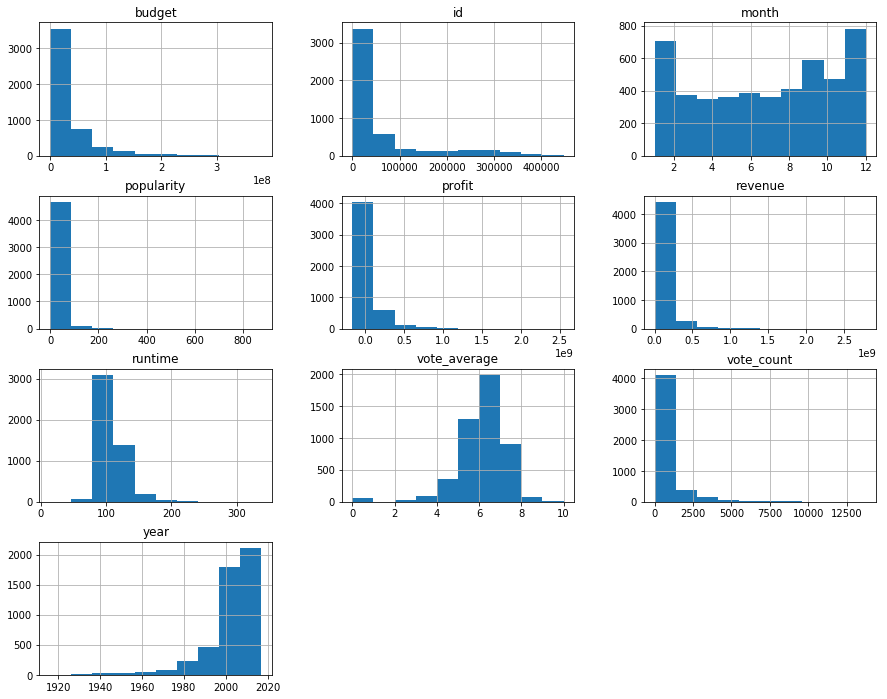

```python
cl_mov.hist(figsize = (15,12));
```

From here, we will observe our variables of interest till now. Other variables that we might find intersting are `year`, `month`, `vote_average` and `popularity`. Following are the observations:

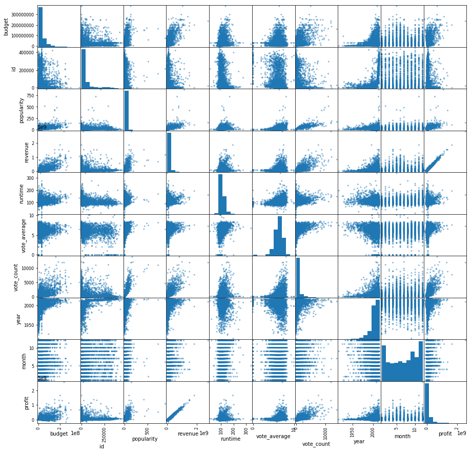

```python
pd.plotting.scatter_matrix(cl_mov, figsize = (15,15));
```

Among these scatterplots we will observe our relations of interest:

1. Profit vs Popularity shows positive but low correlation.
2. Profit vs Revenue shows the highest positive correlation
3. Profit vs Runtime show positive but very low correlation
4. Vote Average vs Runtime also show positive but low correlation
5. Popularity vs runtime also has very low but positive correlation

```python
cl_mov.head()
```

|  | budget | id | popularity | release_date | revenue | runtime | title | vote_average | vote_count | year | month | day | profit |
| --- | --- | --- | --- | --- | --- | --- | --- | --- | --- | --- | --- | --- | --- |
| 0 | 237000000.0 | 19995 | 150.437577 | 2009-12-10 | 2.787965e+09 | 162.0 | Avatar | 7.2 | 11800 | 2009 | 12 | Thursday | 2.550965e+09 |
| 1 | 300000000.0 | 285 | 139.082615 | 2007-05-19 | 9.610000e+08 | 169.0 | Pirates of the Caribbean: At World's End | 6.9 | 4500 | 2007 | 5 | Saturday | 6.610000e+08 |
| 2 | 245000000.0 | 206647 | 107.376788 | 2015-10-26 | 8.806746e+08 | 148.0 | Spectre | 6.3 | 4466 | 2015 | 10 | Monday | 6.356746e+08 |
| 3 | 250000000.0 | 49026 | 112.312950 | 2012-07-16 | 1.084939e+09 | 165.0 | The Dark Knight Rises | 7.6 | 9106 | 2012 | 7 | Monday | 8.349391e+08 |
| 4 | 260000000.0 | 49529 | 43.926995 | 2012-03-07 | 2.841391e+08 | 132.0 | John Carter | 6.1 | 2124 | 2012 | 3 | Wednesday | 2.413910e+07 |

```python
cl_mov.count()
```

```
budget          4792
id              4792
popularity      4792
release_date    4792
revenue         4792
runtime         4792
title           4792
vote_average    4792
vote_count      4792
year            4792
month           4792
day             4792
profit          4792
dtype: int64
```

**12. Now, I have my research questions ready to explore further**

### Research Question 1: Which weekdays as release days turn out to be most lucky for movies in terms of popularity and profit?

**1. To analyze this, first seperate out the variables that you want in your analysis and group them by weekdays with mean of other dependent variables**

```python
# Seperate the necessay variables and groupby weekdays
df1 = cl_mov.groupby('day')[['day', 'profit', 'popularity']]
df1.head(2)
```

|  | day | profit | popularity |
| --- | --- | --- | --- |
| 0 | Thursday | 2.550965e+09 | 150.437577 |
| 1 | Saturday | 6.610000e+08 | 139.082615 |
| 2 | Monday | 6.356746e+08 | 107.376788 |
| 3 | Monday | 8.349391e+08 | 112.312950 |
| 4 | Wednesday | 2.413910e+07 | 43.926995 |
| 5 | Tuesday | 6.328716e+08 | 115.699814 |
| 6 | Wednesday | 3.317949e+08 | 48.681969 |
| 8 | Tuesday | 6.839592e+08 | 98.885637 |
| 11 | Thursday | 3.860907e+08 | 107.928811 |
| 17 | Saturday | 6.657138e+08 | 135.413856 |
| 30 | Friday | 5.837663e+08 | 35.149586 |
| 35 | Friday | 6.862972e+08 | 21.939663 |
| 47 | Sunday | 2.773652e+08 | 78.291018 |
| 57 | Sunday | 3.413119e+08 | 66.390712 |

```python
# Take the mean of dependent variables
df1_v1 = df1.mean()
df1_v1
```

| day | profit | popularity |
| --- | --- | --- |
| Friday | 4.992227e+07 | 16.303436 |
| Monday | 8.237837e+07 | 21.081432 |
| Saturday | 7.156912e+07 | 16.916489 |
| Sunday | 5.899899e+07 | 14.356027 |
| Thursday | 7.575379e+07 | 24.703346 |
| Tuesday | 1.033782e+08 | 26.415341 |
| Wednesday | 1.080997e+08 | 32.694124 |

**Note: If we will plot only using the above data initially, the bar chart will be plotted in the same order as shown above and not the order that weekdays originally have. Therefore we need to do some encoding to get the desired visual.**

**2. Take the overall mean of profit and popularity(dependent variables) for comparison in the graph**

```python
pf_mean = cl_mov.profit.mean()
pf_mean
```

```
71459345.62819387
```

```python
pt_mean = cl_mov.popularity.mean()
pt_mean
```

```
21.540727889607684
```

**3. Define the variables to be used for index, width and xticks**

```python
ind = np.arange(len(df1.nunique()['day']))
width = 0.35
ind + width
```

```
array([0.35, 1.35, 2.35, 3.35, 4.35, 5.35, 6.35])
```

**4. Define the order of weekdays with their id to map with the dataframe**

```python
sorter = ['Monday', 'Tuesday', 'Wednesday', 'Thursday', 'Friday', 'Saturday', 'Sunday']
sorterIndex = dict(zip(sorter,range(len(sorter))))
sorterIndex
```

```
{'Monday': 0,
 'Tuesday': 1,
 'Wednesday': 2,
 'Thursday': 3,
 'Friday': 4,
 'Saturday': 5,
 'Sunday': 6}
```

**5. Map the sorterIndex defined above with the dataframe as a seperate column**

```python
df1_v1['day_id'] = df1_v1.index
df1_v1['day_id'] = df1_v1['day_id'].map(sorterIndex)
df1_v1
```

| day | profit | popularity | day_id |
| --- | --- | --- | --- |
| Friday | 4.992227e+07 | 16.303436 | 4 |
| Monday | 8.237837e+07 | 21.081432 | 0 |
| Saturday | 7.156912e+07 | 16.916489 | 5 |
| Sunday | 5.899899e+07 | 14.356027 | 6 |
| Thursday | 7.575379e+07 | 24.703346 | 3 |
| Tuesday | 1.033782e+08 | 26.415341 | 1 |
| Wednesday | 1.080997e+08 | 32.694124 | 2 |

**6. Sort the values of the dataframe according to the day id defined above for sorting according to the original weekdays order**

```python
df1_v1.sort_values('day_id', inplace = True)
df1_v1
```

| day | profit | popularity | day_id |
| --- | --- | --- | --- |
| Monday | 8.237837e+07 | 21.081432 | 0 |
| Tuesday | 1.033782e+08 | 26.415341 | 1 |
| Wednesday | 1.080997e+08 | 32.694124 | 2 |
| Thursday | 7.575379e+07 | 24.703346 | 3 |
| Friday | 4.992227e+07 | 16.303436 | 4 |
| Saturday | 7.156912e+07 | 16.916489 | 5 |
| Sunday | 5.899899e+07 | 14.356027 | 6 |

**Observations:**

1. Wednesday has the highest average profit i.e 108 Million Dollars for the movies released on that day.
2. Friday has the lowest average profit i.e. 49.9 Million Dollars for the movies released on that day.
3. Wednesday has the highest average popularity too i.e 32.69 units
4. Sunday has the lowest average popularity i.e. 14.35 units

**Now our dataframe is ready to be plotted as a bar chart**

**7. Check the index order to be used as labels for xticks**

```python
df1_v1.index
```

```
Index(['Monday', 'Tuesday', 'Wednesday', 'Thursday', 'Friday', 'Saturday',
       'Sunday'],
      dtype='object', name='day')
```

**8. Plot the bar chart for profit comparisons**

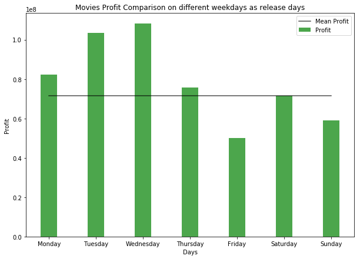

```python
# Define the figure size
plt.figure(figsize=(10, 7))

# Plot the bars and the line
pro = plt.bar(ind, df1_v1['profit'], width, color = 'green', alpha=.7, label='Profit')
plt.plot(ind, np.repeat(pf_mean, 7), '-', color = 'black',  alpha=.7, label='Mean Profit')

# Define labels, xticks and title
plt.ylabel('Profit')
plt.xlabel('Days')
plt.title('Movies Profit Comparison on different weekdays as release days')
plt.xticks(ind, df1_v1.index)

#Plot the legend
plt.legend()
```

**Observations:**

1. Wednesday has the highest average profit and Friday has the lowest average profit for the movies released on those days.
2. Monday, Tuesday, Wednesday and Thursday have average profits above the overall mean profit value.

**9. Plot the bar chart for popularity comparisons**

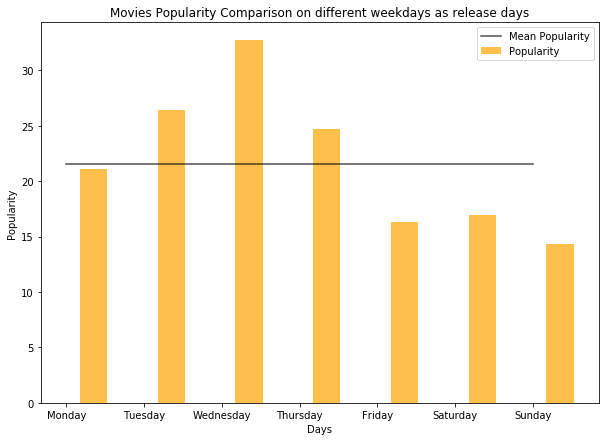

```python
# Define the figure size
plt.figure(figsize=(10, 7))

# Plot the bars and the line
pop = plt.bar(ind+width, df1_v1['popularity'], width, color = 'orange', alpha=.7, label='Popularity')
plt.plot(ind, np.repeat(pt_mean, 7), '-', color = 'black',  alpha=.7, label='Mean Popularity')

# Define labels, xticks and title
plt.ylabel('Popularity')
plt.xlabel('Days')
plt.title('Movies Popularity Comparison on different weekdays as release days')
plt.xticks(ind, df1_v1.index)

# Define Legend
plt.legend()
```

**Observations:**

1. Wednesday has the highest average popularity and Sunday has the lowest average popularity for the movies released on those days.
2. Tuesday, Wednesday and Thursday have average popularities above the overall mean popularity.

### Research Question 2 : How the time duration has been affecting High Profits, High Voting Average and High Popularity over the years from 2007 to 2017 ?

**1. Let's check the number of movies released in each year from 2007 onwards**

```python
cl_mov.query('year >= 2007')['year'].value_counts()
```

```
2009    246
2014    238
2013    231
2008    227
2010    225
2011    221
2015    212
2012    208
2007    195
2016    104
2017      1
Name: year, dtype: int64
```

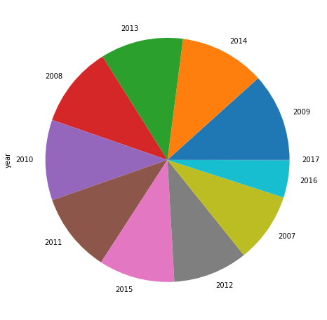

```python
cl_mov.query('year >= 2007')['year'].value_counts().plot(kind = 'pie', figsize = (8,8))
```

**The same has been depicted in the pie chart in the same order. But this is not our main chart. Let's analyze further..**

**2. First form a different dataframe for years above 2007**

```python
df2 = cl_mov.query('year >= 2007')
df2['year'].value_counts()
```

```
2009    246
2014    238
2013    231
2008    227
2010    225
2011    221
2015    212
2012    208
2007    195
2016    104
2017      1
Name: year, dtype: int64
```

```python
df2.head()
```

|  | budget | id | popularity | release_date | revenue | runtime | title | vote_average | vote_count | year | month | day | profit |
| --- | --- | --- | --- | --- | --- | --- | --- | --- | --- | --- | --- | --- | --- |
| 0 | 237000000.0 | 19995 | 150.437577 | 2009-12-10 | 2.787965e+09 | 162.0 | Avatar | 7.2 | 11800 | 2009 | 12 | Thursday | 2.550965e+09 |
| 1 | 300000000.0 | 285 | 139.082615 | 2007-05-19 | 9.610000e+08 | 169.0 | Pirates of the Caribbean: At World's End | 6.9 | 4500 | 2007 | 5 | Saturday | 6.610000e+08 |
| 2 | 245000000.0 | 206647 | 107.376788 | 2015-10-26 | 8.806746e+08 | 148.0 | Spectre | 6.3 | 4466 | 2015 | 10 | Monday | 6.356746e+08 |
| 3 | 250000000.0 | 49026 | 112.312950 | 2012-07-16 | 1.084939e+09 | 165.0 | The Dark Knight Rises | 7.6 | 9106 | 2012 | 7 | Monday | 8.349391e+08 |
| 4 | 260000000.0 | 49529 | 43.926995 | 2012-03-07 | 2.841391e+08 | 132.0 | John Carter | 6.1 | 2124 | 2012 | 3 | Wednesday | 2.413910e+07 |

**3. Group the above dataframe by year**

```python
df2_v1 = df2.groupby('year')[['profit', 'popularity', 'vote_average']].mean()
df2_v1
```

| year | profit | popularity | vote_average |
| --- | --- | --- | --- |
| 2007 | 7.303982e+07 | 18.760907 | 6.088205 |
| 2008 | 6.628028e+07 | 20.629812 | 6.095154 |
| 2009 | 7.597524e+07 | 19.572171 | 6.061789 |
| 2010 | 7.055582e+07 | 21.340839 | 5.968000 |
| 2011 | 7.048262e+07 | 22.135302 | 6.041629 |
| 2012 | 9.727743e+07 | 25.527071 | 5.909615 |
| 2013 | 8.429960e+07 | 28.135912 | 6.089177 |
| 2014 | 9.498064e+07 | 37.480126 | 5.578992 |
| 2015 | 1.019590e+08 | 37.948763 | 5.612264 |
| 2016 | 1.128847e+08 | 37.128692 | 5.833654 |
| 2017 | 5.334153e+07 | 0.710870 | 7.400000 |

**4. We need to categorize films in three categorires : Short, Medium And Long. For that we need to set the ranges for `runtime` to fit the categories.**

```python
# Calculate overall mean runtime
df2.runtime.mean()
```

```
105.72272177221366
```

```python
# Calculate overall runtime minimum
df2.runtime.min()
```

```
14.0
```

```python
# Calculate overall runtime maximum
df2.runtime.max()
```

```
338.0
```

**From the above calculations and the overall trend, we decided the ranges**

**a. 0-100 for short movies**

**b. 100-220 for medium movies**

```python
# Form a dataset for short movies
df2_v2 = df2.query('runtime < 100').groupby('year')[['profit', 'popularity', 'vote_average']].mean()
df2_v2
df2_v2.loc[2017] = 0
df2_v2
```

| year | profit | popularity | vote_average |
| --- | --- | --- | --- |
| 2007 | 6.231636e+07 | 14.367600 | 5.563415 |
| 2008 | 6.253652e+07 | 14.868337 | 5.809000 |
| 2009 | 5.582681e+07 | 16.656147 | 5.859649 |
| 2010 | 6.561910e+07 | 17.240160 | 5.488608 |
| 2011 | 5.268176e+07 | 15.019057 | 5.738462 |
| 2012 | 6.424574e+07 | 19.162335 | 5.729592 |
| 2013 | 6.811670e+07 | 18.018622 | 5.659341 |
| 2014 | 7.061124e+07 | 17.619095 | 4.812871 |
| 2015 | 8.520805e+07 | 24.525652 | 5.064773 |
| 2016 | 9.337499e+07 | 23.171445 | 5.465714 |
| 2017 | 0.000000e+00 | 0.000000 | 0.000000 |

```python
# Form a dataset for medium movies
df2_v3 = df2.query('(runtime >= 100) & (runtime <220)').groupby('year')[['profit', 'popularity', 'vote_average']].mean()
df2_v3
```

| year | profit | popularity | vote_average |
| --- | --- | --- | --- |
| 2007 | 8.106681e+07 | 22.131682 | 6.464286 |
| 2008 | 6.922812e+07 | 25.166407 | 6.320472 |
| 2009 | 9.368176e+07 | 22.242882 | 6.225954 |
| 2010 | 7.385020e+07 | 23.714330 | 6.224138 |
| 2011 | 8.294323e+07 | 27.116673 | 6.253846 |
| 2012 | 1.267057e+08 | 31.197472 | 6.070000 |
| 2013 | 9.481848e+07 | 34.712150 | 6.368571 |
| 2014 | 1.129464e+08 | 52.122199 | 6.143796 |
| 2015 | 1.138467e+08 | 47.474842 | 6.000806 |
| 2016 | 1.227809e+08 | 44.208455 | 6.020290 |
| 2017 | 5.334153e+07 | 0.710870 | 7.400000 |

```python
# Form a dataset for long movies
df2_v4 = df2.query('runtime >= 200').groupby('year')[['profit', 'popularity', 'vote_average']].mean()
df2_v4
df2_v4.loc[2008] = 0
df2_v4.loc[2011] = 0
df2_v4.loc[2012] = 0
df2_v4.loc[2013] = 0
df2_v4.loc[2014] = 0
df2_v4.loc[2015] = 0
df2_v4.loc[2017] = 0
df2_v4
```

| year | profit | popularity | vote_average |
| --- | --- | --- | --- |
| 2007 | 5.334153e+07 | 1.485324 | 7.0 |
| 2009 | 5.334153e+07 | 2.135689 | 7.6 |
| 2010 | -1.712872e+07 | 1.138383 | 6.7 |
| 2016 | 5.334153e+07 | 0.042346 | 0.0 |
| 2008 | 0.000000e+00 | 0.000000 | 0.0 |
| 2011 | 0.000000e+00 | 0.000000 | 0.0 |
| 2012 | 0.000000e+00 | 0.000000 | 0.0 |
| 2013 | 0.000000e+00 | 0.000000 | 0.0 |
| 2014 | 0.000000e+00 | 0.000000 | 0.0 |
| 2015 | 0.000000e+00 | 0.000000 | 0.0 |
| 2017 | 0.000000e+00 | 0.000000 | 0.0 |

**Note: In the above subsets, we kept 0 as values for those years where data was unavailable for the provided range of runtime and df2_v4 has got incorrect index order for years**

**6. Define the order of years with their id to map with the dataframe**

```python
sorter = [2007, 2008, 2009, 2010, 2011, 2012, 2013, 2014, 2015, 2016, 2017]
sorterIndex = dict(zip(sorter,range(len(sorter))))
sorterIndex
```

```
{2007: 0,
 2008: 1,
 2009: 2,
 2010: 3,
 2011: 4,
 2012: 5,
 2013: 6,
 2014: 7,
 2015: 8,
 2016: 9,
 2017: 10}
```

**7. Map the sorterIndex defined above with the dataframe as a seperate column**

```python
df2_v4['year_id'] = df2_v4.index
df2_v4['year_id'] = df2_v4['year_id'].map(sorterIndex)
df2_v4
```

| year | profit | popularity | vote_average | year_id |
| --- | --- | --- | --- | --- |
| 2007 | 5.334153e+07 | 1.485324 | 7.0 | 0 |
| 2009 | 5.334153e+07 | 2.135689 | 7.6 | 2 |
| 2010 | -1.712872e+07 | 1.138383 | 6.7 | 3 |
| 2016 | 5.334153e+07 | 0.042346 | 0.0 | 9 |
| 2008 | 0.000000e+00 | 0.000000 | 0.0 | 1 |
| 2011 | 0.000000e+00 | 0.000000 | 0.0 | 4 |
| 2012 | 0.000000e+00 | 0.000000 | 0.0 | 5 |
| 2013 | 0.000000e+00 | 0.000000 | 0.0 | 6 |
| 2014 | 0.000000e+00 | 0.000000 | 0.0 | 7 |
| 2015 | 0.000000e+00 | 0.000000 | 0.0 | 8 |
| 2017 | 0.000000e+00 | 0.000000 | 0.0 | 10 |

**8. Sort the values of the dataframe according to the year id defined above for sorting according to the original weekdays order**

```python
df2_v4.sort_values('year_id', inplace=True)
df2_v4
```

| year | profit | popularity | vote_average | year_id |
| --- | --- | --- | --- | --- |
| 2007 | 5.334153e+07 | 1.485324 | 7.0 | 0 |
| 2008 | 0.000000e+00 | 0.000000 | 0.0 | 1 |
| 2009 | 5.334153e+07 | 2.135689 | 7.6 | 2 |
| 2010 | -1.712872e+07 | 1.138383 | 6.7 | 3 |
| 2011 | 0.000000e+00 | 0.000000 | 0.0 | 4 |
| 2012 | 0.000000e+00 | 0.000000 | 0.0 | 5 |
| 2013 | 0.000000e+00 | 0.000000 | 0.0 | 6 |
| 2014 | 0.000000e+00 | 0.000000 | 0.0 | 7 |
| 2015 | 0.000000e+00 | 0.000000 | 0.0 | 8 |
| 2016 | 5.334153e+07 | 0.042346 | 0.0 | 9 |
| 2017 | 0.000000e+00 | 0.000000 | 0.0 | 10 |

**9. define the variables to be used for locations and width of the bars and xticks**

```python
ind2 = np.arange(len(df2_v4['year_id']))
width = 0.35
ind2 + 2*width
```

```
array([ 0.7,  1.7,  2.7,  3.7,  4.7,  5.7,  6.7,  7.7,  8.7,  9.7, 10.7])
```

**10. Plot the bar graph for the profit comparisons with runtime**

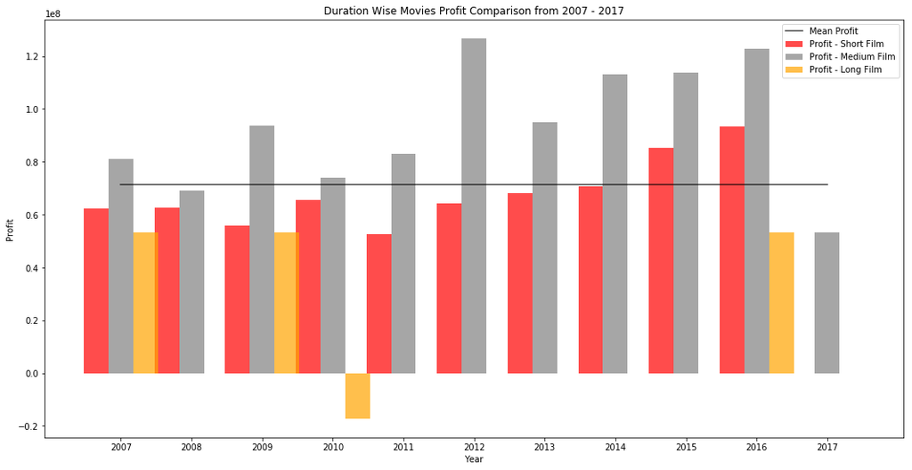

```python
# Set the figure size
plt.figure(figsize=(18, 9))

# Plot the bars and the line
pro1 = plt.bar(ind2, df2_v2['profit'], width, color = 'red', alpha=.7, label='Profit - Short Film')
pro2 = plt.bar(ind2 + width, df2_v3['profit'], width, color = 'grey', alpha=.7, label='Profit - Medium Film')
pro3 = plt.bar(ind2 + 2*width, df2_v4['profit'], width, color = 'orange', alpha=.7, label='Profit - Long Film')
plt.plot(ind2 + width, np.repeat(pf_mean, 11), '-', color = 'black',  alpha=.7, label='Mean Profit')

# Plot the labels, xticks and title
plt.ylabel('Profit')
plt.xlabel('Year')
plt.title('Duration Wise Movies Profit Comparison from 2007 - 2017')
plt.xticks(ind2 + width, df2_v4.index)

# set the legend
plt.legend()
```

**10. Plot the bar graph for the popularity comparisons with runtime**

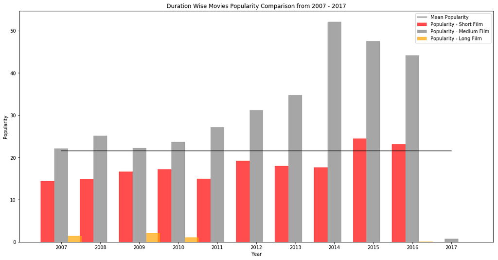

```python
# Set the figure size
plt.figure(figsize=(18, 9))

# Plot the bars and the line
pop1 = plt.bar(ind2, df2_v2['popularity'], width, color = 'red', alpha=.7, label='Popularity - Short Film')
pop2 = plt.bar(ind2 + width, df2_v3['popularity'], width, color = 'grey', alpha=.7, label='Popularity - Medium Film')
pop3 = plt.bar(ind2 + 2*width, df2_v4['popularity'], width, color = 'orange', alpha=.7, label='Popularity - Long Film')
plt.plot(ind2 + width, np.repeat(pt_mean, 11), '-', color = 'black',  alpha=.7, label='Mean Popularity')

# Plot the labels, xticks and title
plt.ylabel('Popularity')
plt.xlabel('Year')
plt.title('Duration Wise Movies Popularity Comparison from 2007 - 2017')
plt.xticks(ind2 + width, df2_v4.index)

# Set the legend
plt.legend()
```

**10. Plot the bar graph for the vote average comparisons with runtime**

```python
# Calculate overall mean of vote averages
vt_mean = cl_mov.vote_average.mean()
vt_mean
```

```
6.0955968280467445
```

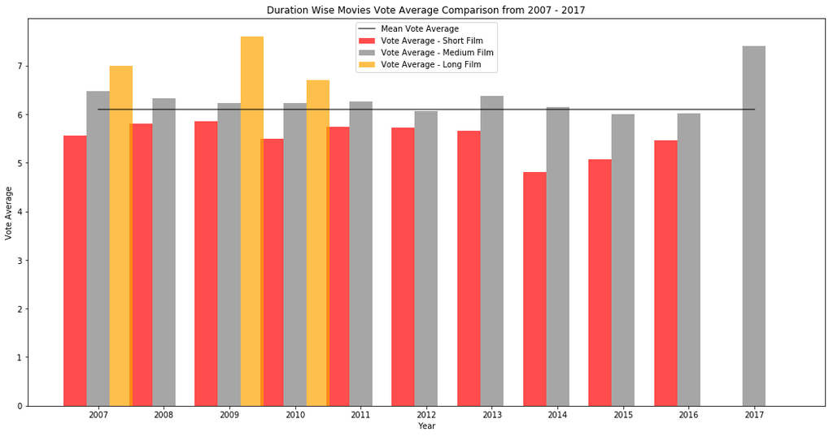

```python
# Set the figure size
plt.figure(figsize=(18, 9))

# Plot the bars and the line
vot1 = plt.bar(ind2, df2_v2['vote_average'], width, color = 'red', alpha=.7, label='Vote Average - Short Film')
vot2 = plt.bar(ind2 + width, df2_v3['vote_average'], width, color = 'grey', alpha=.7, label='Vote Average - Medium Film')
vot3 = plt.bar(ind2 + 2*width, df2_v4['vote_average'], width, color = 'orange', alpha=.7, label='Vote Average - Long Film')
plt.plot(ind2 + width, np.repeat(vt_mean, 11), '-', color = 'black',  alpha=.7, label='Mean Vote Average')

# Plot the labels, xticks and title
plt.ylabel('Vote Average')
plt.xlabel('Year')
plt.title('Duration Wise Movies Vote Average Comparison from 2007 - 2017')
plt.xticks(ind2 + width, df2_v4.index)

# Set the legend
plt.legend()
```

## Conclusions

Here I conclude my analysis for TMDB Movies Dataset with the summary of the observations from the above two areas of interest:

**Research Question 1: Which weekdays as release days turn out to be most lucky for movies in terms of popularity and profit?**

**Research Question 2 : How the time duration has been affecting High Profits, High Voting Average and High Popularity over the years from 2007 to 2017 ?**

**Note: The above analysis was done at its best but there were limitations to the analysis due to high number of missing data and incapability to explore some variables**

## References

1. [TMDB Movies Dataset](https://d17h27t6h515a5.cloudfront.net/topher/2017/October/59dd1c4c_tmdb-movies/tmdb-movies.csv)
2. [Pandas Documentation](https://pandas.pydata.org/pandas-docs/stable/)
3. [Matplotlib Documentation](https://matplotlib.org/)